# Results: lab_2.sas

The REG Procedure

| Number of Observations Read | 143 |
| --- | --- |
| Number of Observations Used | 143 |

| Descriptive Statistics Variable | Descriptive Statistics Sum | Descriptive Statistics Mean | Descriptive Statistics Uncorrected SS | Descriptive Statistics Variance | Descriptive Statistics Standard Deviation |
| --- | --- | --- | --- | --- | --- |
| Intercept | 143.00000 | 1.00000 | 143.00000 | 0 | 0 |
| adult_mortality | 21497 | 150.32867 | 4489745 | 8860.06727 | 94.12793 |
| infant_deaths | 227.95516 | 1.59409 | 724.36075 | 2.54211 | 1.59440 |
| alcohol | 432.05000 | 3.02133 | 3619.07550 | 16.29374 | 4.03655 |
| hepatitis_b | 11798 | 82.50350 | 1054890 | 574.04048 | 23.95914 |
| measles | 422.73136 | 2.95616 | 2475.00163 | 8.62915 | 2.93754 |
| bmi | 6099.60000 | 42.65455 | 323370 | 445.02898 | 21.09571 |
| under_five_deaths | 250.20001 | 1.74965 | 841.79791 | 2.84532 | 1.68681 |
| polio | 11878 | 83.06294 | 1069542 | 583.94672 | 24.16499 |
| total_expenditure | 858.21000 | 6.00147 | 6064.62370 | 6.43735 | 2.53719 |
| diphtheria | 12089 | 84.53846 | 1091717 | 491.06717 | 22.16004 |
| hiv_aids | 91.90000 | 0.64266 | 319.07000 | 1.83105 | 1.35316 |
| gdp | 1112.34813 | 7.77866 | 9023.69924 | 2.61354 | 1.61665 |
| thinness_1_19_years | 658.40000 | 4.60420 | 5550.34000 | 17.73900 | 4.21177 |
| thinness_5_9_years | 669.00000 | 4.67832 | 5758.76000 | 18.51382 | 4.30277 |
| income_composition_of_resources | 98.63300 | 0.68974 | 71.27594 | 0.02285 | 0.15116 |
| schooling | 1846.80000 | 12.91469 | 24969 | 7.87281 | 2.80585 |
| life_expectancy | 10238 | 71.59161 | 740967 | 56.62303 | 7.52483 |

| Correlation Variable | Correlation adult_mortality | Correlation infant_deaths | Correlation alcohol | Correlation hepatitis_b | Correlation measles | Correlation bmi | Correlation under_five_deaths | Correlation polio | Correlation total_expenditure | Correlation diphtheria | Correlation hiv_aids | Correlation gdp | Correlation thinness_1_19_years | Correlation thinness_5_9_years | Correlation income_composition_of_resources | Correlation schooling | Correlation life_expectancy |
| --- | --- | --- | --- | --- | --- | --- | --- | --- | --- | --- | --- | --- | --- | --- | --- | --- | --- |
| adult_mortality | 1.0000 | 0.4106 | -0.2819 | -0.2256 | 0.1718 | -0.3648 | 0.4282 | -0.3674 | -0.2101 | -0.3185 | 0.6676 | -0.3388 | 0.2450 | 0.2539 | -0.6158 | -0.5050 | -0.7589 |
| infant_deaths | 0.4106 | 1.0000 | -0.3358 | -0.2876 | 0.5456 | -0.4504 | 0.9953 | -0.3476 | -0.1950 | -0.3638 | 0.2826 | -0.4128 | 0.4994 | 0.5083 | -0.5932 | -0.5473 | -0.5800 |
| alcohol | -0.2819 | -0.3358 | 1.0000 | 0.1847 | -0.0375 | 0.4149 | -0.3364 | 0.2886 | 0.3395 | 0.2484 | -0.2521 | 0.4366 | -0.3947 | -0.3870 | 0.5884 | 0.5804 | 0.5217 |
| hepatitis_b | -0.2256 | -0.2876 | 0.1847 | 1.0000 | -0.1105 | 0.1580 | -0.2958 | 0.5154 | 0.0822 | 0.8964 | -0.3409 | 0.1497 | -0.0140 | -0.0667 | 0.3175 | 0.3087 | 0.3944 |
| measles | 0.1718 | 0.5456 | -0.0375 | -0.1105 | 1.0000 | -0.1799 | 0.5463 | -0.1765 | -0.1724 | -0.1496 | 0.0401 | -0.0704 | 0.3411 | 0.3556 | -0.1875 | -0.1764 | -0.2055 |
| bmi | -0.3648 | -0.4504 | 0.4149 | 0.1580 | -0.1799 | 1.0000 | -0.4535 | 0.1848 | 0.1903 | 0.1712 | -0.2743 | 0.3825 | -0.4514 | -0.4744 | 0.6172 | 0.5906 | 0.5382 |
| under_five_deaths | 0.4282 | 0.9953 | -0.3364 | -0.2958 | 0.5463 | -0.4535 | 1.0000 | -0.3549 | -0.1957 | -0.3769 | 0.3053 | -0.4253 | 0.4978 | 0.5043 | -0.6149 | -0.5669 | -0.6059 |
| polio | -0.3674 | -0.3476 | 0.2886 | 0.5154 | -0.1765 | 0.1848 | -0.3549 | 1.0000 | 0.2068 | 0.5857 | -0.3596 | 0.2902 | -0.1418 | -0.1481 | 0.4623 | 0.3921 | 0.4827 |
| total_expenditure | -0.2101 | -0.1950 | 0.3395 | 0.0822 | -0.1724 | 0.1903 | -0.1957 | 0.2068 | 1.0000 | 0.1022 | -0.0658 | 0.1102 | -0.2524 | -0.2790 | 0.2595 | 0.3273 | 0.3413 |
| diphtheria | -0.3185 | -0.3638 | 0.2484 | 0.8964 | -0.1496 | 0.1712 | -0.3769 | 0.5857 | 0.1022 | 1.0000 | -0.4008 | 0.2564 | -0.0539 | -0.1099 | 0.4250 | 0.3840 | 0.4818 |
| hiv_aids | 0.6676 | 0.2826 | -0.2521 | -0.3409 | 0.0401 | -0.2743 | 0.3053 | -0.3596 | -0.0658 | -0.4008 | 1.0000 | -0.2157 | 0.1513 | 0.1349 | -0.4693 | -0.3631 | -0.6426 |
| gdp | -0.3388 | -0.4128 | 0.4366 | 0.1497 | -0.0704 | 0.3825 | -0.4253 | 0.2902 | 0.1102 | 0.2564 | -0.2157 | 1.0000 | -0.2607 | -0.2595 | 0.6368 | 0.5576 | 0.5209 |
| thinness_1_19_years | 0.2450 | 0.4994 | -0.3947 | -0.0140 | 0.3411 | -0.4514 | 0.4978 | -0.1418 | -0.2524 | -0.0539 | 0.1513 | -0.2607 | 1.0000 | 0.9682 | -0.4759 | -0.4769 | -0.4345 |
| thinness_5_9_years | 0.2539 | 0.5083 | -0.3870 | -0.0667 | 0.3556 | -0.4744 | 0.5043 | -0.1481 | -0.2790 | -0.1099 | 0.1349 | -0.2595 | 0.9682 | 1.0000 | -0.4742 | -0.4732 | -0.4368 |
| income_composition_of_resources | -0.6158 | -0.5932 | 0.5884 | 0.3175 | -0.1875 | 0.6172 | -0.6149 | 0.4623 | 0.2595 | 0.4250 | -0.4693 | 0.6368 | -0.4759 | -0.4742 | 1.0000 | 0.9133 | 0.9102 |
| schooling | -0.5050 | -0.5473 | 0.5804 | 0.3087 | -0.1764 | 0.5906 | -0.5669 | 0.3921 | 0.3273 | 0.3840 | -0.3631 | 0.5576 | -0.4769 | -0.4732 | 0.9133 | 1.0000 | 0.8072 |
| life_expectancy | -0.7589 | -0.5800 | 0.5217 | 0.3944 | -0.2055 | 0.5382 | -0.6059 | 0.4827 | 0.3413 | 0.4818 | -0.6426 | 0.5209 | -0.4345 | -0.4368 | 0.9102 | 0.8072 | 1.0000 |

The REG Procedure

Model: MODEL1

Dependent Variable: life_expectancy

| Number of Observations Read | 143 |
| --- | --- |
| Number of Observations Used | 143 |

| Analysis of Variance Source | Analysis of Variance DF | Analysis of Variance Sum of Squares | Analysis of Variance Mean Square | Analysis of Variance F Value | Analysis of Variance Pr > F |
| --- | --- | --- | --- | --- | --- |
| Model | 16 | 7492.98693 | 468.31168 | 107.78 | <.0001 |
| Error | 126 | 547.48300 | 4.34510 |  |  |
| Corrected Total | 142 | 8040.46993 |  |  |  |

| Root MSE | 2.08449 | R-Square | 0.9319 |
| --- | --- | --- | --- |
| Dependent Mean | 71.59161 | Adj R-Sq | 0.9233 |
| Coeff Var | 2.91164 |  |  |

| Parameter Estimates Variable | Parameter Estimates DF | Parameter Estimates Parameter Estimate | Parameter Estimates Standard Error | Parameter Estimates t Value | Parameter Estimates Pr > \|t\| |
| --- | --- | --- | --- | --- | --- |
| Intercept | 1 | 51.06485 | 1.94884 | 26.20 | <.0001 |
| adult_mortality | 1 | -0.01587 | 0.00295 | -5.38 | <.0001 |
| infant_deaths | 1 | 2.20101 | 1.22508 | 1.80 | 0.0748 |
| alcohol | 1 | -0.01190 | 0.05845 | -0.20 | 0.8390 |
| hepatitis_b | 1 | 0.03925 | 0.01718 | 2.28 | 0.0241 |
| measles | 1 | 0.03332 | 0.07635 | 0.44 | 0.6632 |
| bmi | 1 | -0.01370 | 0.01134 | -1.21 | 0.2292 |
| under_five_deaths | 1 | -2.31572 | 1.18740 | -1.95 | 0.0534 |
| polio | 1 | -0.00849 | 0.00968 | -0.88 | 0.3821 |
| total_expenditure | 1 | 0.36324 | 0.07897 | 4.60 | <.0001 |
| diphtheria | 1 | -0.01557 | 0.02038 | -0.76 | 0.4463 |
| hiv_aids | 1 | -0.84956 | 0.19081 | -4.45 | <.0001 |
| gdp | 1 | -0.20521 | 0.14625 | -1.40 | 0.1630 |
| thinness_1_19_years | 1 | -0.06486 | 0.18108 | -0.36 | 0.7208 |
| thinness_5_9_years | 1 | 0.01463 | 0.17746 | 0.08 | 0.9344 |
| income_composition_of_resources | 1 | 38.81588 | 3.79089 | 10.24 | <.0001 |
| schooling | 1 | -0.29570 | 0.16519 | -1.79 | 0.0758 |

The REG Procedure

Model: MODEL1

Dependent Variable: life_expectancy

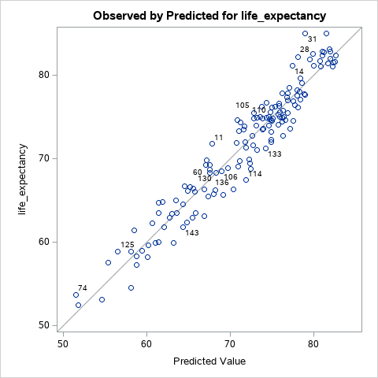

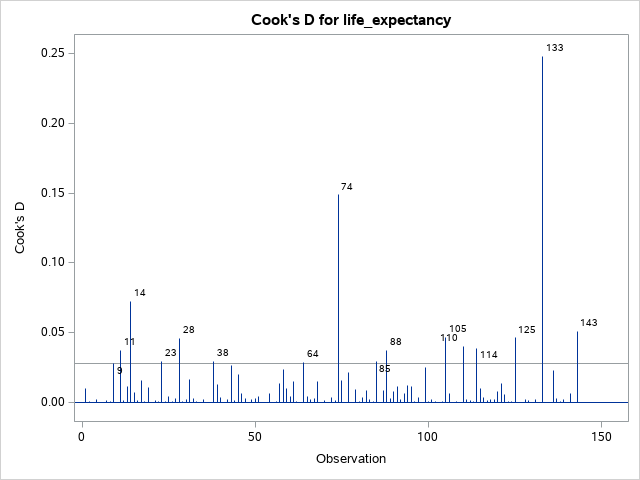

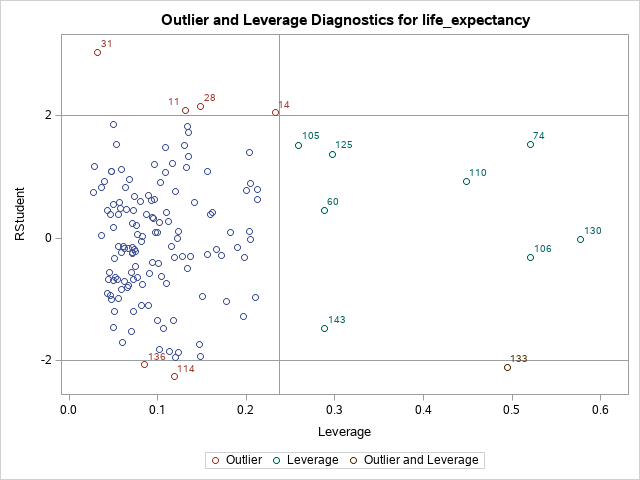

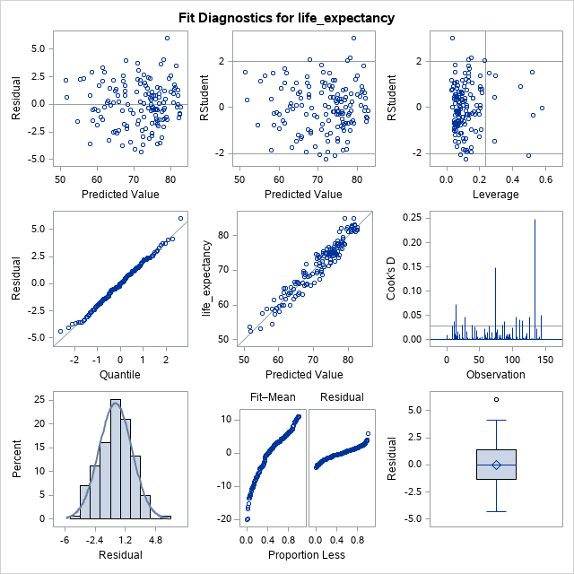

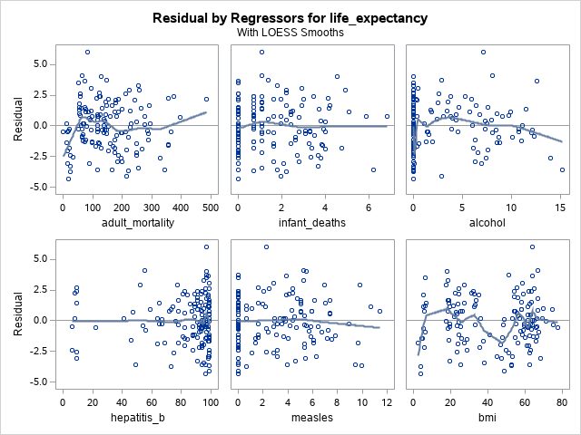

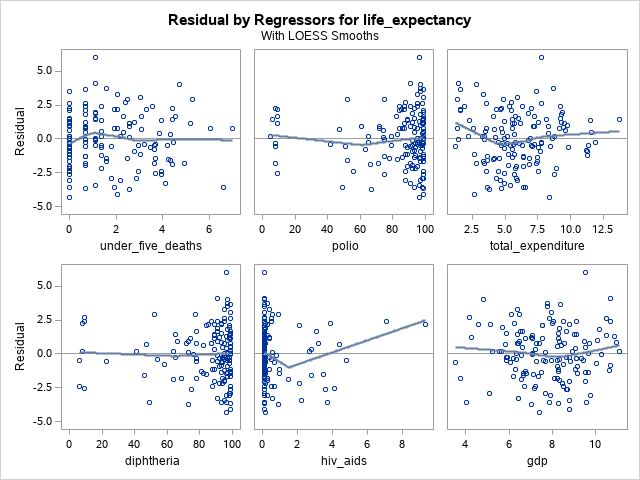

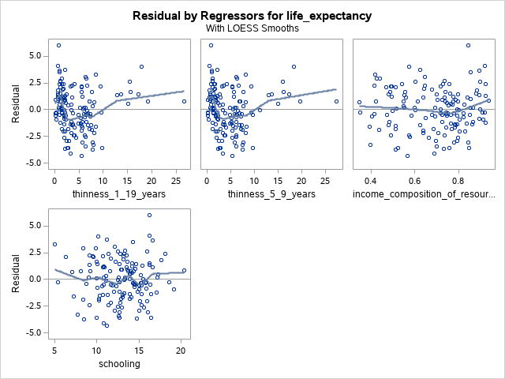

The UNIVARIATE Procedure

Variable: liekanos (Residual)

| Moments |  |  |  |
| --- | --- | --- | --- |
| N | 143 | Sum Weights | 143 |
| Mean | 0 | Sum Observations | 0 |
| Std Deviation | 1.9635463 | Variance | 3.85551409 |
| Skewness | 0.07581444 | Kurtosis | -0.1986175 |
| Uncorrected SS | 547.483 | Corrected SS | 547.483 |
| Coeff Variation | . | Std Error Mean | 0.16419999 |

| Basic Statistical Measures Location | Basic Statistical Measures Location | Basic Statistical Measures Variability | Basic Statistical Measures Variability |
| --- | --- | --- | --- |
| Mean | 0.00000 | Std Deviation | 1.96355 |
| Median | -0.02942 | Variance | 3.85551 |
| Mode | . | Range | 10.37170 |
|  |  | Interquartile Range | 2.75851 |

| Tests for Location: Mu0=0 Test | Tests for Location: Mu0=0 Statistic | Tests for Location: Mu0=0 Statistic | Tests for Location: Mu0=0 p Value | Tests for Location: Mu0=0 p Value |
| --- | --- | --- | --- | --- |
| Student's t | t | 0 | Pr > \|t\| | 1.0000 |
| Sign | M | -0.5 | Pr >= \|M\| | 1.0000 |
| Signed Rank | S | -7 | Pr >= \|S\| | 0.9888 |

| Tests for Normality Test | Tests for Normality Statistic | Tests for Normality Statistic | Tests for Normality p Value | Tests for Normality p Value |
| --- | --- | --- | --- | --- |
| Shapiro-Wilk | W | 0.993603 | Pr < W | 0.7765 |
| Kolmogorov-Smirnov | D | 0.037915 | Pr > D | >0.1500 |
| Cramer-von Mises | W-Sq | 0.022271 | Pr > W-Sq | >0.2500 |
| Anderson-Darling | A-Sq | 0.16701 | Pr > A-Sq | >0.2500 |

| Quantiles (Definition 5) Level | Quantiles (Definition 5) Quantile |
| --- | --- |
| 100% Max | 6.0185761 |
| 99% | 4.0756452 |
| 95% | 3.0754193 |
| 90% | 2.3855185 |
| 75% Q3 | 1.3772214 |
| 50% Median | -0.0294188 |
| 25% Q1 | -1.3812901 |
| 10% | -2.6117692 |
| 5% | -3.4252599 |
| 1% | -4.0648715 |
| 0% Min | -4.3531283 |

| Extreme Observations Lowest Value | Extreme Observations Lowest Obs | Extreme Observations Highest Value | Extreme Observations Highest Obs |
| --- | --- | --- | --- |
| -4.35313 | 114 | 3.69040 | 14 |
| -4.06487 | 136 | 3.71759 | 59 |
| -3.75464 | 85 | 4.00469 | 11 |
| -3.67389 | 88 | 4.07565 | 28 |
| -3.59712 | 99 | 6.01858 | 31 |

The REG Procedure

Model: MODEL1

Dependent Variable: life_expectancy

| Number of Observations Read | 143 |
| --- | --- |
| Number of Observations Used | 143 |

Stepwise Selection: Step 1

Variable income_composition_of_resources Entered: R-Square = 0.8285 and C(p) = 178.3957

| Analysis of Variance Source | Analysis of Variance DF | Analysis of Variance Sum of Squares | Analysis of Variance Mean Square | Analysis of Variance F Value | Analysis of Variance Pr > F |
| --- | --- | --- | --- | --- | --- |
| Model | 1 | 6661.35306 | 6661.35306 | 681.05 | <.0001 |
| Error | 141 | 1379.11687 | 9.78097 |  |  |
| Corrected Total | 142 | 8040.46993 |  |  |  |

| Variable | Parameter Estimate | Standard Error | Type II SS | F Value | Pr > F |
| --- | --- | --- | --- | --- | --- |
| Intercept | 40.33937 | 1.22577 | 10593 | 1083.03 | <.0001 |
| income_composition_of_resources | 45.31009 | 1.73622 | 6661.35306 | 681.05 | <.0001 |

Bounds on condition number: 1, 1

Stepwise Selection: Step 2

Variable adult_mortality Entered: R-Square = 0.8919 and C(p) = 63.0759

| Analysis of Variance Source | Analysis of Variance DF | Analysis of Variance Sum of Squares | Analysis of Variance Mean Square | Analysis of Variance F Value | Analysis of Variance Pr > F |
| --- | --- | --- | --- | --- | --- |
| Model | 2 | 7171.11942 | 3585.55971 | 577.42 | <.0001 |
| Error | 140 | 869.35051 | 6.20965 |  |  |
| Corrected Total | 142 | 8040.46993 |  |  |  |

| Variable | Parameter Estimate | Standard Error | Type II SS | F Value | Pr > F |
| --- | --- | --- | --- | --- | --- |
| Intercept | 50.93659 | 1.52377 | 6938.84921 | 1117.43 | <.0001 |
| adult_mortality | -0.02555 | 0.00282 | 509.76636 | 82.09 | <.0001 |
| income_composition_of_resources | 35.51404 | 1.75577 | 2540.56106 | 409.13 | <.0001 |

Bounds on condition number: 1.6108, 6.4432

Stepwise Selection: Step 3

Variable hiv_aids Entered: R-Square = 0.9081 and C(p) = 35.0081

| Analysis of Variance Source | Analysis of Variance DF | Analysis of Variance Sum of Squares | Analysis of Variance Mean Square | Analysis of Variance F Value | Analysis of Variance Pr > F |
| --- | --- | --- | --- | --- | --- |
| Model | 3 | 7301.76734 | 2433.92245 | 457.99 | <.0001 |
| Error | 139 | 738.70259 | 5.31441 |  |  |
| Corrected Total | 142 | 8040.46993 |  |  |  |

| Variable | Parameter Estimate | Standard Error | Type II SS | F Value | Pr > F |
| --- | --- | --- | --- | --- | --- |
| Intercept | 50.84484 | 1.40978 | 6912.68270 | 1300.74 | <.0001 |
| adult_mortality | -0.01716 | 0.00311 | 161.88620 | 30.46 | <.0001 |
| hiv_aids | -0.95681 | 0.19297 | 130.64792 | 24.58 | <.0001 |
| income_composition_of_resources | 34.71043 | 1.63235 | 2402.95952 | 452.16 | <.0001 |

Bounds on condition number: 2.2883, 17.211

Stepwise Selection: Step 4

Variable total_expenditure Entered: R-Square = 0.9199 and C(p) = 15.1580

| Analysis of Variance Source | Analysis of Variance DF | Analysis of Variance Sum of Squares | Analysis of Variance Mean Square | Analysis of Variance F Value | Analysis of Variance Pr > F |
| --- | --- | --- | --- | --- | --- |
| Model | 4 | 7396.70811 | 1849.17703 | 396.40 | <.0001 |
| Error | 138 | 643.76182 | 4.66494 |  |  |
| Corrected Total | 142 | 8040.46993 |  |  |  |

| Variable | Parameter Estimate | Standard Error | Type II SS | F Value | Pr > F |
| --- | --- | --- | --- | --- | --- |
| Intercept | 49.51954 | 1.35310 | 6247.93397 | 1339.34 | <.0001 |
| adult_mortality | -0.01555 | 0.00293 | 130.93396 | 28.07 | <.0001 |
| total_expenditure | 0.33693 | 0.07469 | 94.94078 | 20.35 | <.0001 |
| hiv_aids | -1.05659 | 0.18215 | 156.96986 | 33.65 | <.0001 |
| income_composition_of_resources | 33.44193 | 1.55499 | 2157.60182 | 462.51 | <.0001 |

Bounds on condition number: 2.3228, 27.787

Stepwise Selection: Step 5

Variable hepatitis_b Entered: R-Square = 0.9247 and C(p) = 8.4164

| Analysis of Variance Source | Analysis of Variance DF | Analysis of Variance Sum of Squares | Analysis of Variance Mean Square | Analysis of Variance F Value | Analysis of Variance Pr > F |
| --- | --- | --- | --- | --- | --- |
| Model | 5 | 7434.69132 | 1486.93826 | 336.28 | <.0001 |
| Error | 137 | 605.77861 | 4.42174 |  |  |
| Corrected Total | 142 | 8040.46993 |  |  |  |

| Variable | Parameter Estimate | Standard Error | Type II SS | F Value | Pr > F |
| --- | --- | --- | --- | --- | --- |
| Intercept | 48.31111 | 1.38038 | 5416.16894 | 1224.89 | <.0001 |
| adult_mortality | -0.01644 | 0.00287 | 144.75699 | 32.74 | <.0001 |
| hepatitis_b | 0.02352 | 0.00803 | 37.98320 | 8.59 | 0.0040 |
| total_expenditure | 0.33092 | 0.07274 | 91.51193 | 20.70 | <.0001 |
| hiv_aids | -0.92312 | 0.18309 | 112.40387 | 25.42 | <.0001 |
| income_composition_of_resources | 32.50282 | 1.54745 | 1950.74236 | 441.17 | <.0001 |

Bounds on condition number: 2.3492, 41.794

All variables left in the model are significant at the 0.0500 level.

No other variable met the 0.0500 significance level for entry into the model.

| Summary of Stepwise Selection Step | Summary of Stepwise Selection Variable Entered | Summary of Stepwise Selection Variable Removed | Summary of Stepwise Selection Number Vars In | Summary of Stepwise Selection Partial R-Square | Summary of Stepwise Selection Model R-Square | Summary of Stepwise Selection C(p) | Summary of Stepwise Selection F Value | Summary of Stepwise Selection Pr > F |
| --- | --- | --- | --- | --- | --- | --- | --- | --- |
| 1 | income_composition_of_resources |  | 1 | 0.8285 | 0.8285 | 178.396 | 681.05 | <.0001 |
| 2 | adult_mortality |  | 2 | 0.0634 | 0.8919 | 63.0759 | 82.09 | <.0001 |
| 3 | hiv_aids |  | 3 | 0.0162 | 0.9081 | 35.0081 | 24.58 | <.0001 |
| 4 | total_expenditure |  | 4 | 0.0118 | 0.9199 | 15.1580 | 20.35 | <.0001 |
| 5 | hepatitis_b |  | 5 | 0.0047 | 0.9247 | 8.4164 | 8.59 | 0.0040 |

The REG Procedure

Model: MODEL1

Dependent Variable: life_expectancy

| Number of Observations Read | 143 |
| --- | --- |
| Number of Observations Used | 143 |

| Analysis of Variance Source | Analysis of Variance DF | Analysis of Variance Sum of Squares | Analysis of Variance Mean Square | Analysis of Variance F Value | Analysis of Variance Pr > F |
| --- | --- | --- | --- | --- | --- |
| Model | 5 | 7434.69132 | 1486.93826 | 336.28 | <.0001 |
| Error | 137 | 605.77861 | 4.42174 |  |  |
| Corrected Total | 142 | 8040.46993 |  |  |  |

| Root MSE | 2.10279 | R-Square | 0.9247 |
| --- | --- | --- | --- |
| Dependent Mean | 71.59161 | Adj R-Sq | 0.9219 |
| Coeff Var | 2.93721 |  |  |

| Parameter Estimates Variable | Parameter Estimates DF | Parameter Estimates Parameter Estimate | Parameter Estimates Standard Error | Parameter Estimates t Value | Parameter Estimates Pr > \|t\| | Parameter Estimates Standardized Estimate | Parameter Estimates Squared Partial Corr Type II | Parameter Estimates Variance Inflation | Parameter Estimates 95% Confidence Limits | Parameter Estimates 95% Confidence Limits |
| --- | --- | --- | --- | --- | --- | --- | --- | --- | --- | --- |
| Intercept | 1 | 48.31111 | 1.38038 | 35.00 | <.0001 | 0 | . | 0 | 45.58151 | 51.04071 |
| adult_mortality | 1 | -0.01644 | 0.00287 | -5.72 | <.0001 | -0.20565 | 0.19287 | 2.34916 | -0.02212 | -0.01076 |
| hepatitis_b | 1 | 0.02352 | 0.00803 | 2.93 | 0.0040 | 0.07489 | 0.05900 | 1.18739 | 0.00765 | 0.03939 |
| total_expenditure | 1 | 0.33092 | 0.07274 | 4.55 | <.0001 | 0.11158 | 0.13124 | 1.09388 | 0.18708 | 0.47476 |
| hiv_aids | 1 | -0.92312 | 0.18309 | -5.04 | <.0001 | -0.16600 | 0.15651 | 1.97117 | -1.28517 | -0.56107 |
| income_composition_of_resources | 1 | 32.50282 | 1.54745 | 21.00 | <.0001 | 0.65293 | 0.76305 | 1.75717 | 29.44284 | 35.56280 |

The REG Procedure

Model: MODEL1

Dependent Variable: life_expectancy

| Output Statistics Obs | Output Statistics Dependent Variable | Output Statistics Predicted Value | Output Statistics Std Error Mean Predict | Output Statistics 95% CL Predict | Output Statistics 95% CL Predict | Output Statistics Residual |
| --- | --- | --- | --- | --- | --- | --- |
| 1 | 65.0 | 63.6931 | 0.5260 | 59.4069 | 67.9793 | 1.3069 |
| 2 | 77.8 | 76.0836 | 0.2556 | 71.8948 | 80.2723 | 1.7164 |
| 3 | 75.6 | 76.6766 | 0.3584 | 72.4585 | 80.8947 | -1.0766 |
| 4 | 76.4 | 77.5570 | 0.3847 | 73.3298 | 81.7841 | -1.1570 |
| 5 | 76.3 | 76.9552 | 0.2751 | 72.7617 | 81.1488 | -0.6552 |
| 6 | 74.8 | 74.0570 | 0.2375 | 69.8725 | 78.2416 | 0.7430 |
| 7 | 82.8 | 83.0088 | 0.3833 | 78.7822 | 87.2354 | -0.2088 |
| 8 | 81.5 | 82.0399 | 0.4298 | 77.7958 | 86.2840 | -0.5399 |
| 9 | 72.7 | 75.2920 | 0.2095 | 71.1133 | 79.4707 | -2.5920 |
| 10 | 76.9 | 77.7874 | 0.2933 | 73.5890 | 81.9858 | -0.8874 |
| 11 | 71.8 | 68.0020 | 0.3710 | 63.7796 | 72.2243 | 3.7980 |
| 12 | 75.5 | 77.1685 | 0.2383 | 72.9838 | 81.3533 | -1.6685 |
| 13 | 72.3 | 75.1454 | 0.3415 | 70.9328 | 79.3580 | -2.8454 |
| 14 | 81.1 | 78.9236 | 0.4990 | 74.6499 | 83.1972 | 2.1764 |
| 15 | 71.0 | 72.3235 | 0.2306 | 68.1405 | 76.5066 | -1.3235 |
| 16 | 60.0 | 62.3759 | 0.3313 | 58.1665 | 66.5854 | -2.3759 |
| 17 | 69.8 | 67.5224 | 0.3144 | 63.3181 | 71.7267 | 2.2776 |
| 18 | 77.4 | 76.1474 | 0.3172 | 71.9422 | 80.3526 | 1.2526 |
| 19 | 65.7 | 68.7834 | 0.3625 | 64.5639 | 73.0028 | -3.0834 |
| 20 | 75.0 | 75.4028 | 0.2695 | 71.2106 | 79.5949 | -0.4028 |
| 21 | 77.7 | 78.2245 | 0.4168 | 73.9855 | 82.4635 | -0.5245 |
| 22 | 74.5 | 76.6657 | 0.2781 | 72.4714 | 80.8600 | -2.1657 |
| 23 | 59.9 | 64.0803 | 0.7226 | 59.6835 | 68.4771 | -4.1803 |
| 24 | 59.6 | 60.8325 | 0.5297 | 56.5444 | 65.1205 | -1.2325 |
| 25 | 73.3 | 71.0824 | 0.2652 | 66.8913 | 75.2735 | 2.2176 |
| 26 | 68.7 | 67.3755 | 0.2865 | 63.1790 | 71.5721 | 1.3245 |
| 27 | 57.3 | 59.2501 | 0.4833 | 54.9835 | 63.5166 | -1.9501 |
| 28 | 82.2 | 78.8103 | 0.5981 | 74.4872 | 83.1333 | 3.3897 |
| 29 | 52.5 | 51.4964 | 0.5708 | 47.1878 | 55.8051 | 1.0036 |
| 30 | 53.1 | 54.9597 | 0.4775 | 50.6956 | 59.2237 | -1.8597 |

[output cut: 113 more lines]

| Sum of Residuals | 0 |
| --- | --- |
| Sum of Squared Residuals | 605.77861 |
| Predicted Residual SS (PRESS) | 683.83022 |

| Obs | _MODEL_ | _TYPE_ | _DEPVAR_ | _RMSE_ | Intercept | adult_mortality | infant_deaths | alcohol | hepatitis_b | measles | bmi | under_five_deaths | polio | total_expenditure | diphtheria | hiv_aids | thinness_1_19_years | thinness_5_9_years | income_composition_of_resources | schooling | gdp | life_expectancy | _IN_ | _P_ | _EDF_ | _RSQ_ | _AIC_ | _BIC_ |
| --- | --- | --- | --- | --- | --- | --- | --- | --- | --- | --- | --- | --- | --- | --- | --- | --- | --- | --- | --- | --- | --- | --- | --- | --- | --- | --- | --- | --- |
| 1 | MODEL1 | PARMS | life_expectancy | 2.10279 | 48.3111 | -0.016440 | . | . | 0.023522 | . | . | . | . | 0.33092 | . | -0.92312 | . | . | 32.5028 | . | . | -1 | 5 | 6 | 137 | 0.92466 | 218.445 | 220.752 |